# NYPD Crime Statistics(2014-2015)

Dataset sourced from:https://www.kaggle.com/adamschroeder/crimes-new-york-city

In this dataset, each row represents a crime which has been registered in the NYPD for the years 2014 and 2015. It has specific details of the crime such as time and date of occurence, type of offence, location etc. With this notebook, I aim to do some exploratory analysis on the data and see if some interesting patterns emerge. The data was mostly clean except for the date column which was extremely messy, having dates in different formats, some using '-' as separator, some using '/'. I used Excel and the built in pandas funcitonalities to fix this.

Please use the **'Show/Hide Code'** button below to show the code behind the graphs.

```python
from IPython.display import HTML

HTML('''<script>
code_show=true;
function code_toggle() {
 if (code_show){
 $('div.input').hide();
 } else {
 $('div.input').show();
 }
 code_show = !code_show
}
$( document ).ready(code_toggle);
</script>
<form action="javascript:code_toggle()"><input type="submit" value="Show/Hide Code"></form>''')
```

```python
#all the import statements

import pandas as pd
import numpy as np
import seaborn as sns
import matplotlib.pyplot as plt
%matplotlib inline
```

```python
#Reading data

#data = pd.read_csv('NYPD_Complaint_Data_Historic.csv')
#data['CMPLNT_FR_DT'] = data['CMPLNT_FR_DT'].str.replace('/','-')
#data.to_csv('nypd_datefixed.csv', index=False)

data = pd.read_csv('nypd_datefixed.csv', parse_dates=['CMPLNT_FR_DT'])
```

```python
#Code to get the day of the week, hour, year and month in a separate column

data['CMPLNT_FR_DT'] = pd.to_datetime(data['CMPLNT_FR_DT'], errors='coerce')
data['Day'] = data['CMPLNT_FR_DT'].dt.day_name()
data['CMPLNT_FR_TM'] = pd.to_datetime(data['CMPLNT_FR_TM'], errors='coerce')
data['Hour'] = data['CMPLNT_FR_TM'].dt.hour
data['Year'] = data['CMPLNT_FR_DT'].dt.year
data['Month'] = data['CMPLNT_FR_DT'].dt.month
```

```python
#Renaming some columns for ease of use

data.rename(columns={'BORO_NM':'Borough', 'OFNS_DESC':'Offence Type', 'LAW_CAT_CD':'Crime Class',
                     'PREM_TYP_DESC':'Location Type'}, inplace=True)
```

## 1.Most common crimes in each boroughs

Top 10 most common crimes in each boroughs

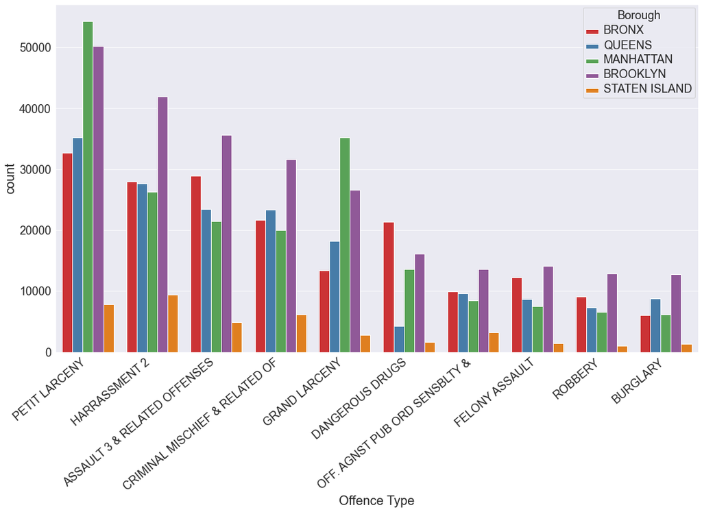

```python
sns.set_style("darkgrid")
fig_dims = (18, 10)
fig, ax = plt.subplots(figsize=fig_dims)
ax.set_xticklabels(ax.get_xticklabels(), rotation=40, ha="right")
ax.tick_params(labelsize=18)
ax.set_xlabel('Offence Type', fontsize=20)
ax.set_ylabel('Count', fontsize=20)
ax = sns.countplot(x='Offence Type', data=data, hue='Borough', palette='Set1',
              order=data['Offence Type'].value_counts().iloc[:10].index)


plt.setp(ax.get_legend().get_texts(), fontsize='18')
plt.setp(ax.get_legend().get_title(), fontsize='18')
plt.show()
```

### Observations:

```
1. Petit larceny is the most common crime, which according to wikipedia is defined as a crime involving the unlawful
   taking or theft of the personal property of another person or business.

2. Highest number of crimes are reported from Brooklyn followed by Manhattan. This can possibly be due to Brooklyn
   being the most populous of the 5 boroughs. But Queens is as populous as Brooklyn which leads me to believe that
   socio-economic factors are at play here.

3. Staten Island has the least crimes on account of it being the least populous of the boroughs.
```

## 2.Next most common offences by borough

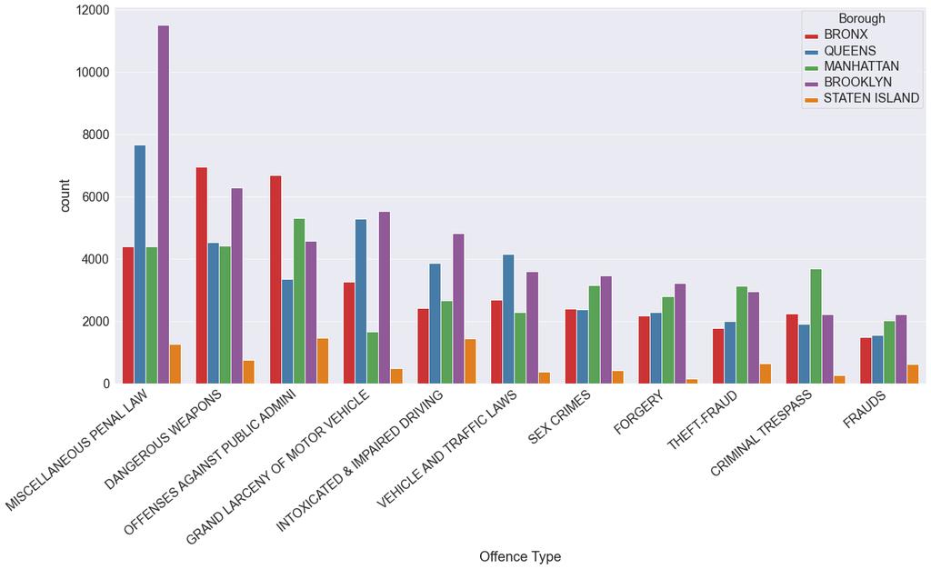

```python
sns.set_style("darkgrid")
fig_dims = (21, 10)
fig, ax = plt.subplots(figsize=fig_dims)
ax.set_xticklabels(ax.get_xticklabels(), rotation=40, ha="right")
ax.tick_params(labelsize=18)
ax.set_xlabel('Offence Type', fontsize=20)
ax.set_ylabel('Count', fontsize=20)
ax = sns.countplot(x='Offence Type', data=data, hue='Borough', palette='Set1',
              order=data['Offence Type'].value_counts().iloc[10:21].index)


plt.setp(ax.get_legend().get_texts(), fontsize='18')
plt.setp(ax.get_legend().get_title(), fontsize='18')
plt.show()
```

## 3.Hours and days which are most criminally active

This is a heatmap with days of the week in the rows and Hours of the day in the columns.

```python
#make pivot table with value counts as value

data['ones'] = 1
pivot_day_hour = data.pivot_table(values='ones', index='Day', columns='Hour', aggfunc='sum')
pivot_day_hour.index = pd.CategoricalIndex(pivot_day_hour.index, categories= ["Sunday", "Monday", "Tuesday", "Wednesday",
                                                                              "Thursday", "Friday", "Saturday"])
pivot_day_hour.sort_index(level=0, inplace=True)
```

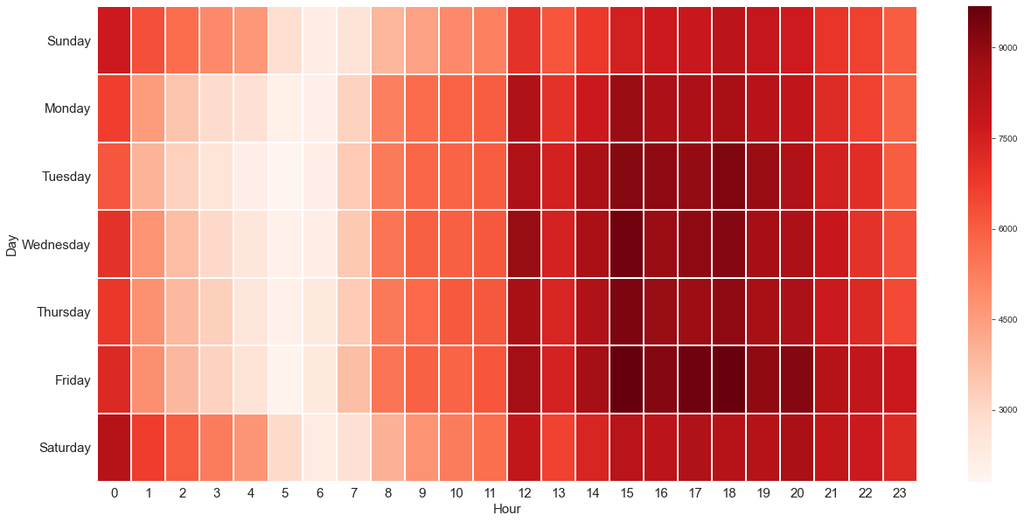

```python
fig_dims = (21, 10)
fig, ax = plt.subplots(figsize=fig_dims)
ax.set_xlabel("Hour",fontsize=15)
ax.set_ylabel("Day",fontsize=15)
ax.tick_params(labelsize=15)

ax = sns.heatmap(pivot_day_hour,cmap='Reds',linecolor='white',linewidths=1)
```

### Observations:

[output not shown]

## 4.Variation of class of crimes by month

Here we look at how the number of crimes varies by month while also looking at breakup of the class of offences, ie Felony, Misdemeanor or Violation

```
[None, None]
```

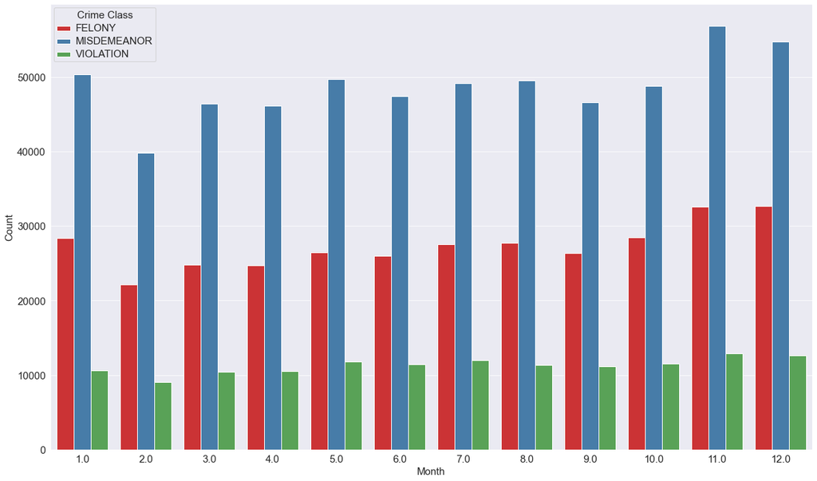

```python
fig_dims = (20, 12)
fig, ax = plt.subplots(figsize=fig_dims)
#ax.set(xticklabels=months)
#ax.set_xticklabels(labels=[i for i in months], rotation=40, ha="right")
sns.countplot(x='Month', data=data, hue='Crime Class', palette='Set1')
ax.set_xlabel("Month",fontsize=15)
ax.set_ylabel("Count",fontsize=15)
ax.tick_params(labelsize=15)
plt.setp(ax.get_legend().get_texts(), fontsize='15')
plt.setp(ax.get_legend().get_title(), fontsize='15')
```

### Observations:

```
 There is not much variation in crimes by month but the colder months of November, December and January has the highest number of serious crimes, with Violations remaining constant throughout the year.
```

## 5.Most common offences in parks

The most common crimes from parks and other public recreational areas

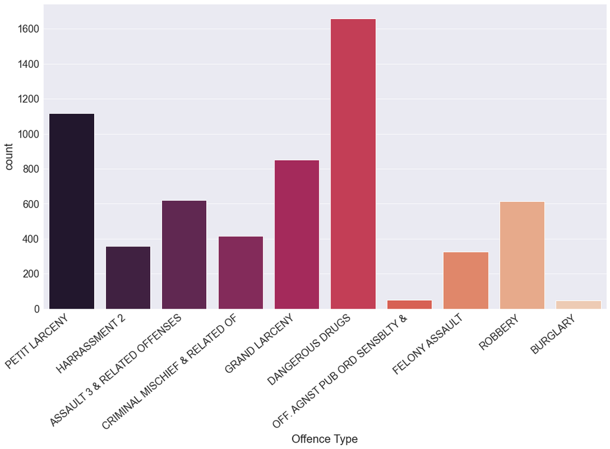

```python
sns.set_style("darkgrid")
fig_dims = (18, 10)
fig, ax = plt.subplots(figsize=fig_dims)
ax.tick_params(labelsize=18)
ax.set_xlabel('Offence Type', fontsize=20)
ax.set_ylabel('Count', fontsize=20)
ax.set_xticklabels(ax.get_xticklabels(), rotation=40, ha="right")
sns.countplot(x='Offence Type', data=data[data['PARKS_NM'].notnull()], palette='rocket',
             order=data['Offence Type'].value_counts().iloc[:10].index)
```

### Observations

The most common crimes in parks are quite predictably Drugs and petty theft, with drugs being ahead by a significant margin.

## 6.Locations where most crimes occur

Heatmap of the locations where the most crimes occur and the hours in which they occur

```python
#make pivot table

pivot_prem_hour = data.pivot_table(values='ones', index='Hour', columns='Location Type', aggfunc='sum')
```

```python
#discard values less than 1000, take transpose to make groph neat

for i in pivot_prem_hour.columns:
    if not any(pivot_prem_hour[i] > 1000):
        pivot_prem_hour.drop(i,axis=1,inplace=True)

pivot_prem_hour = pivot_prem_hour.transpose()
```

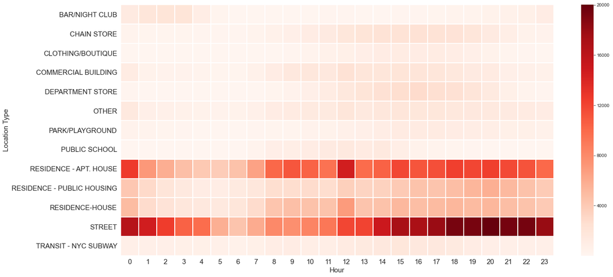

```python
fig_dims = (21, 10)
fig, ax = plt.subplots(figsize=fig_dims)
ax.set_xlabel("Hour",fontsize=15)
ax.set_ylabel("Day",fontsize=15)
ax.tick_params(labelsize=15)

ax = sns.heatmap(pivot_prem_hour,cmap='Reds',linecolor='white',linewidths=1)
```

### Observations:

[output not shown]

## 6(a).Locations where most Felonies occur

Heatmap of the locations where the most felonies occur and the hours in which they occur

```python
pivot_prem_hour_f = data[data['Crime Class']=='FELONY'].pivot_table(values='ones', index='Hour', columns='Location Type',
                                                                  aggfunc='sum')
```

```python
for i in pivot_prem_hour_f.columns:
    if not any(pivot_prem_hour_f[i] > 250):
        pivot_prem_hour_f.drop(i,axis=1,inplace=True)

pivot_prem_hour_f = pivot_prem_hour_f.transpose()
```

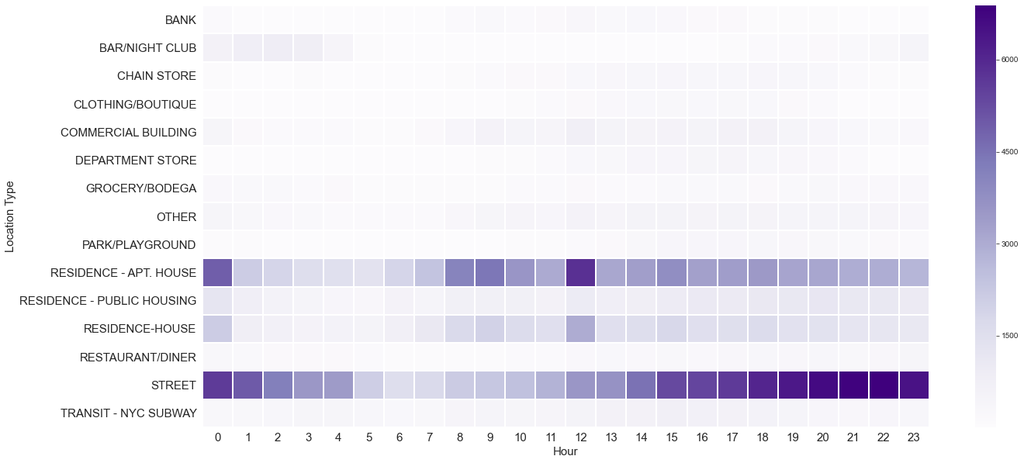

```python
fig_dims = (21, 10)
fig, ax = plt.subplots(figsize=fig_dims)
ax.set_xlabel("Hour",fontsize=15)
ax.set_ylabel("Day",fontsize=15)
ax.tick_params(labelsize=15)

ax = sns.heatmap(pivot_prem_hour_f,cmap='Purples',linecolor='white',linewidths=1)
```

## 6(b).Locations where most Misdemeanors occur

Heatmap of the locations where the most misdemeanors occur and the hours in which they occur

```python
pivot_prem_hour_m = data[data['Crime Class']=='MISDEMEANOR'].pivot_table(values='ones', index='Hour', columns='Location Type',
                                                                  aggfunc='sum')
```

```python
for i in pivot_prem_hour_m.columns:
    if not any(pivot_prem_hour_m[i] > 250):
        pivot_prem_hour_m.drop(i,axis=1,inplace=True)

pivot_prem_hour_m = pivot_prem_hour_m.transpose()
```

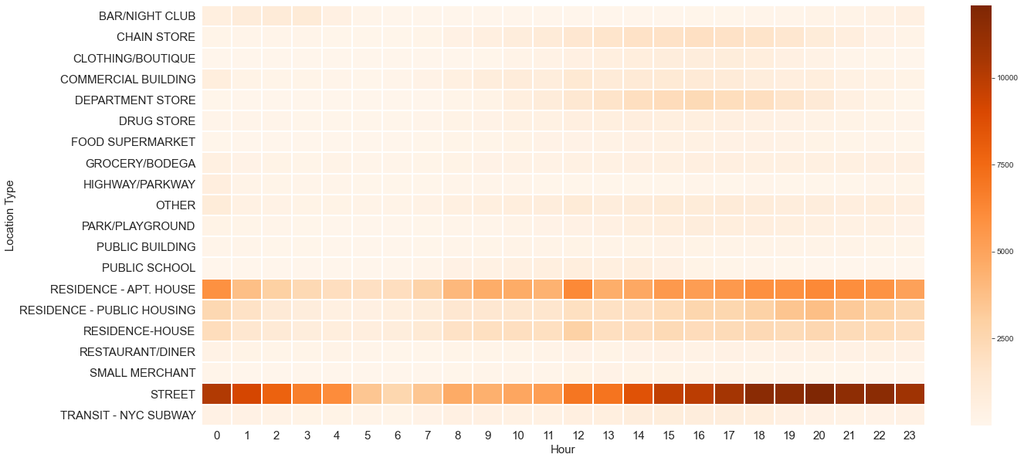

```python
fig_dims = (21, 10)
fig, ax = plt.subplots(figsize=fig_dims)
ax.set_xlabel("Hour",fontsize=15)
ax.set_ylabel("Day",fontsize=15)
ax.tick_params(labelsize=15)

ax = sns.heatmap(pivot_prem_hour_m,cmap='Oranges',linecolor='white',linewidths=1)
```

## 6(c).Locations where most Violations occur

Heatmap of the locations where the most crimes occur and the hours in which they occur

```python
pivot_prem_hour_v = data[data['Crime Class']=='VIOLATION'].pivot_table(values='ones', index='Hour', columns='Location Type',
                                                                  aggfunc='sum')
```

```python
for i in pivot_prem_hour_v.columns:
    if not any(pivot_prem_hour_v[i] > 100):
        pivot_prem_hour_v.drop(i,axis=1,inplace=True)

pivot_prem_hour_v = pivot_prem_hour_v.transpose()
```

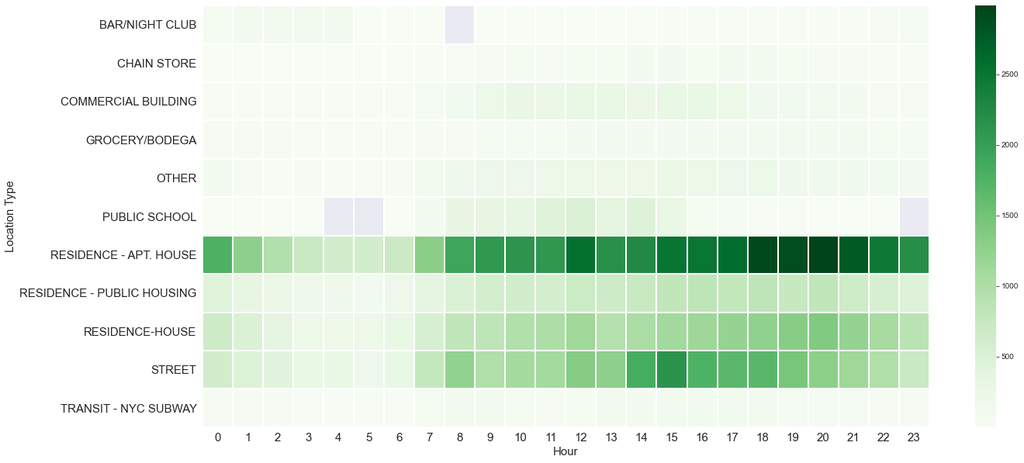

```python
fig_dims = (21, 10)
fig, ax = plt.subplots(figsize=fig_dims)
ax.set_xlabel("Hour",fontsize=15)
ax.set_ylabel("Day",fontsize=15)
ax.tick_params(labelsize=15)

ax = sns.heatmap(pivot_prem_hour_v,cmap='Greens',linecolor='white',linewidths=1)
```

### Observations:

```
Serious crimes(Felonies and misdemeanors) occur more in the streets than compared to houses
```